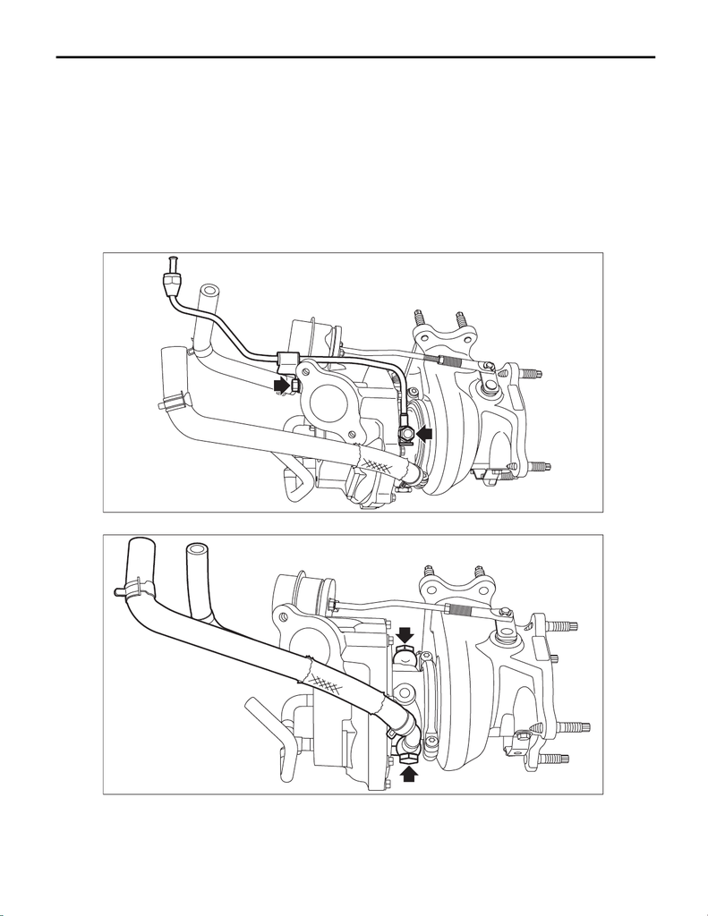

IN(w/o STI)-45

Turbocharger

INTAKE (INDUCTION)

8. Turbocharger

A: REMOVAL

Remove the turbo charger and front exhaust pipe as a unit. Refer to “Front Exhaust Pipe” for the removal pro-

cedure. <Ref. to EX(w/o STI)-9, REMOVAL, Front Exhaust Pipe.> <Ref. to EX(w/o STI)-29, DISASSEMBLY,

Front Exhaust Pipe.>

B: INSTALLATION

Refer to “Front Exhaust Pipe” for the installation procedure. <Ref. to EX(w/o STI)-19, INSTALLATION, Front

Exhaust Pipe.> <Ref. to EX(w/o STI)-32, ASSEMBLY, Front Exhaust Pipe.>

C: DISASSEMBLY

1) Remove the union screw pipe assembly from the turbocharger.

2) Remove the turbocharger pipe from the turbocharger.

IN-03251

IN-03586

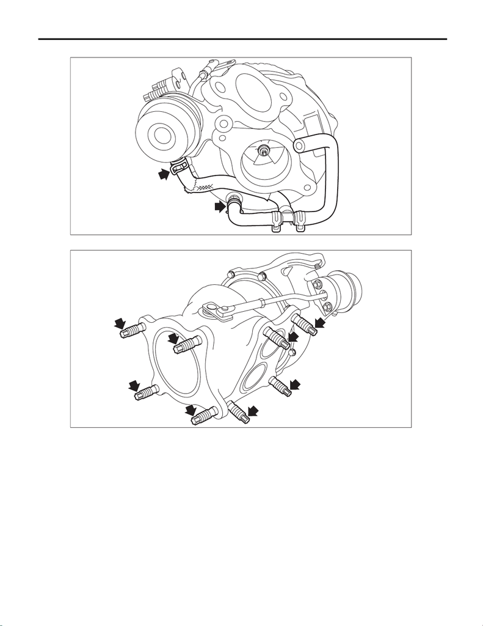

IN(w/o STI)-46

Turbocharger

INTAKE (INDUCTION)

3) Remove the air control hose from the turbocharger.

4) Remove the stud bolt from the turbocharger.

IN-03253

IN-03254

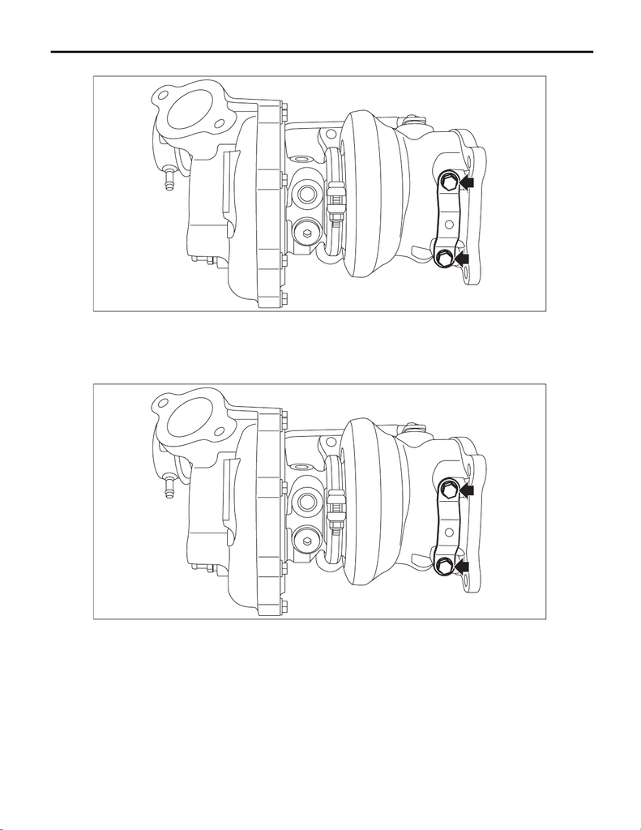

IN(w/o STI)-47

Turbocharger

INTAKE (INDUCTION)

5) Remove the exhaust stay from the turbocharger.

D: ASSEMBLY

1) Install the exhaust stay to the turbocharger.

Tightening torque:

6.4 N·m (0.7 kgf-m, 4.7 ft-lb)

IN-03255

IN-03255

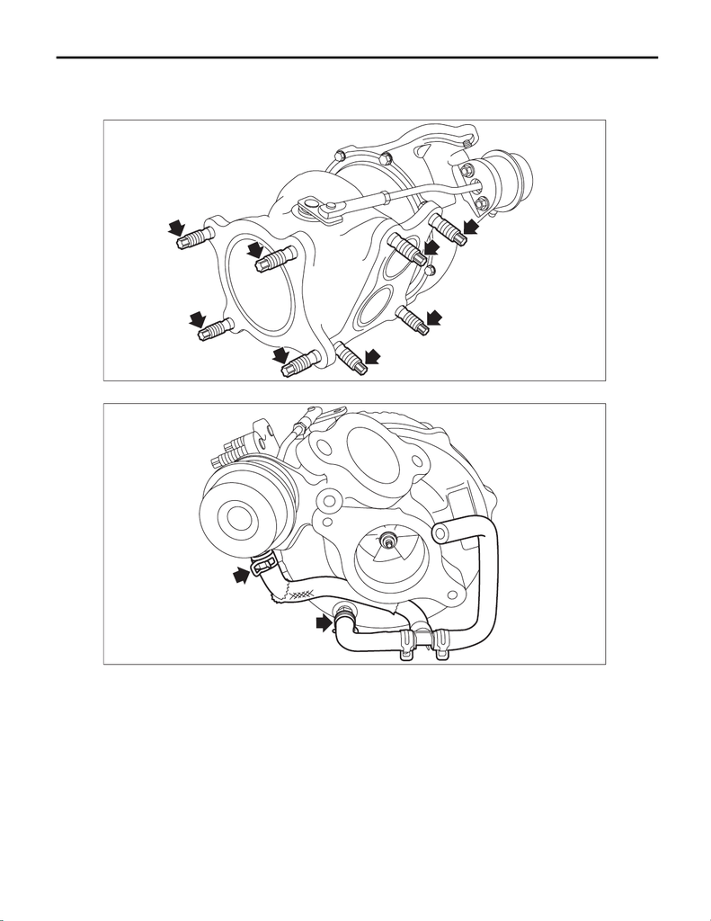

IN(w/o STI)-48

Turbocharger

INTAKE (INDUCTION)

2) Attach the stud bolts to the turbocharger.

Tightening torque:

14.7 N·m (1.5 kgf-m, 10.8 ft-lb)

3) Install the air control hose to the turbocharger.

IN-03254

IN-03253

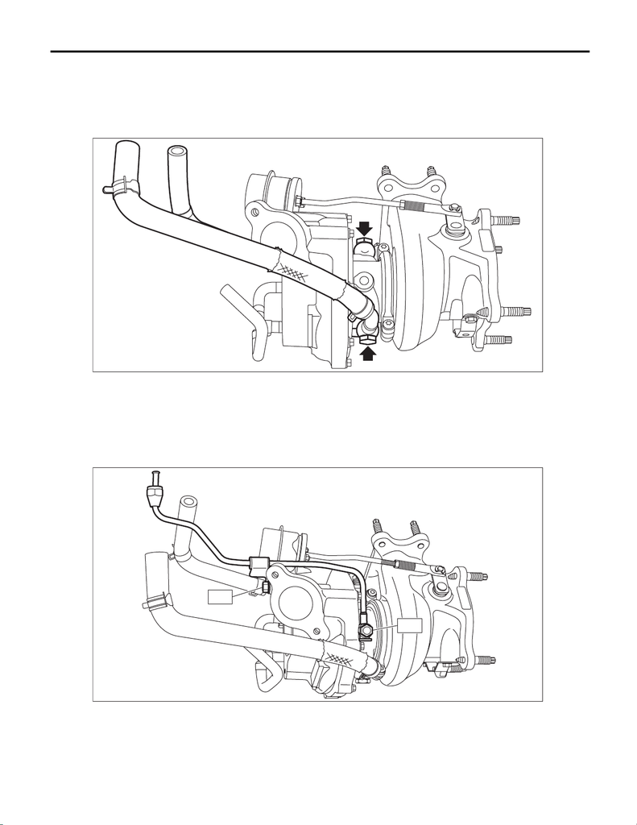

IN(w/o STI)-49

Turbocharger

INTAKE (INDUCTION)

4) Install the turbocharger pipe to the turbocharger.

NOTE:

Use a new gasket.

Tightening torque:

31.5 N·m (3.2 kgf-m, 23.2 ft-lb)

5) Install the union screw pipe assembly to the turbocharger.

NOTE:

Use a new gasket.

Tightening torque:

T1: 6.4 N·m (0.7 kgf-m, 4.7 ft-lb)

T2: 16 N·m (1.6 kgf-m, 11.8 ft-lb)

IN-03586

IN-03256

T2

T1

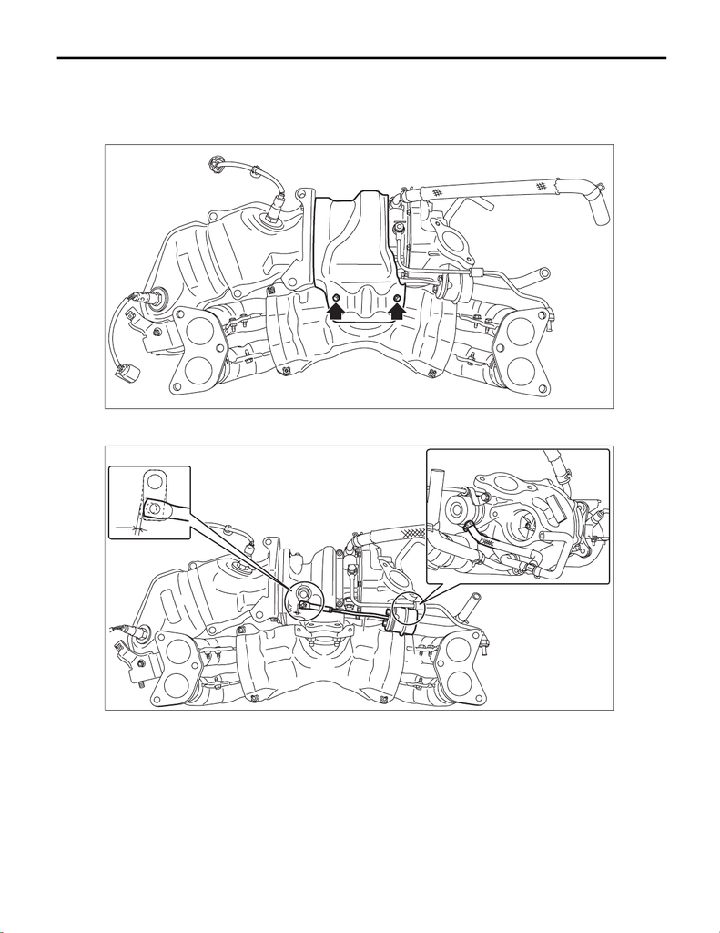

IN(w/o STI)-50

Turbocharger

INTAKE (INDUCTION)

E: INSPECTION

1. WASTE GATE ACTUATOR

1) Remove the front exhaust pipe. <Ref. to EX(w/o STI)-9, REMOVAL, Front Exhaust Pipe.>

2) Remove the exhaust cover.

3) Remove the vacuum control hose (B) from the waste gate actuator (A) of the turbocharger, and connect

the Mighty Vac to the waste gate actuator (A).

(A) Waste gate actuator (C) Control rod (D) Control rod stroke

(B) Vacuum control hose

EX-02991

IN-03337

(D)

(A)

(C)

(B)

[figure not shown]

IN(w/o STI)-51

Turbocharger

INTAKE (INDUCTION)

4) Pressurize slowly with the Mighty Vac, and check the pressure when the control rod stroke (D) becomes

1±0.15 mm (0.0394±0.0059 in). If it is not within the standard, replace the turbocharger assembly.

CAUTION:

Do not pressurize over 112.7 kPa (1.15 kg/cm

2

, 16.34 psi) to prevent damaging the waste gate actua-

tor.

Operating pressure (control rod stroke 1

±

0.15 mm (0.0394

±

0.0059 in)):

Standard

84.0 — 88.0 kPa (0.86 — 0.90 kg/cm

2

, 12.18 — 12.76 psi)

5) After inspection, install the related parts in the reverse order of removal.

Tightening torque:

6.4 N·m (0.7 kgf-m, 4.7 ft-lb)

2. OTHER INSPECTIONS

1) Check that the turbocharger and pipe have no deformation, cracks or other damages.

2) Check that the hose has no cracks, damage or loose part.

3) Check that there are no oil leakage or water leakage from the pipe attachment section.